# 第5回 指数関数・対数関数の経済への応用２

経済学基礎数学II

第5回

指数関数・対数関数の  
経済への応用２

連続時間、AKモデル

経済学基礎数学II

第5回 — Topic01

連続成長率

刻みを細かくすると、階段が曲線になる

## 第5回の道のり

1 連続  
の成長率

2  
対数の傾き

3 足し算  
と引き算

4  
AK と貯蓄率

✎  
計算ドリル5

いまココ — 前に出てきた連続複利を、階段の絵で追い直す

## 前回の振り返り

前回のポイント — 第4回「連続複利」

Q: 年 $3$ % を細かく分けて利息をつけると、  
$1$ 年後の倍率はどうなるか

- **行き先がある**: どれだけ細かくしても $e^{0.03} \approx 1.030455$ 倍を超えない
- **連続複利の式**: 元金 $P$ が $t$ 年後に $Pe^{rt}$
- **$2$ 通りの年 $3$ %**: 前年比なら $1.03$ 倍。$100$ 万円・$1$ 年で約 $455$ 円ちがう

今回は、  
細かくしていく途中を階段の絵で追い、国の GDP に当てる

## このトピックで学ぶこと

- **刻みを細かくする**：年 $12$ % を、年 $1$ 回から毎日まで分ける
- **階段と曲線**：残高の階段が、なめらかな曲線に重なる
- **連続成長率**：曲線の式の、右上の数にある $r$ を読む
- **GDP の式**：$t$ 年後の値を STEP $3$ つで出す

GDP は $1$ 年に $1$ 回まとめて増えるのではなく、  
毎日少しずつ増える。だから連続で測る

## 年 12 % を刻んだ残高

[figure not shown]

$100$ 万円を $1$ 年。毎月を毎日にして増えるのは、数千円か $1000$ 円未満か

## 3 か月ごとの倍率

表に無い「$3$ か月ごと（年 $4$ 回）」の行を、手で足す

$1$ 回の利率

$0.12 \div 4$

$= 0.03$

年 $12$ % を $4$ つに分けた

倍率

$1.03^{4}$

$= 1.03^{2} \times 1.03^{2}$

$4$ 回かけるのを $2$ 回ずつ

$1.03^{2}$

$= 1.0609$

まず $2$ 回ぶん

$1.0609^{2}$

$\approx 1.12551$

もう $2$ 回ぶん

半年 $1.1236$ と毎月 $1.126825$ のあいだ。  
細かくするほど $e^{0.12} \approx 1.1275$ に近づく

## $e$ が出てくる理由

年 $100$ % を $n$ 回に刻むと、$1$ 回の利息は $100$ % $\div\ n$. $1$ 回の倍率は $1 + \frac{1}{n}$

| 刻む回数 $n$ | $1$ | $2$ | $12$ | $365$ | 行き先 |
| --- | --- | --- | --- | --- | --- |
| $1$ 回の倍率 $1 + \frac{1}{n}$ | $2$ | $1.5$ | $\approx 1.0833$ | $\approx 1.0027$ |  |
| $n$ 回掛ける $\left(1 + \frac{1}{n}\right)^{n}$ | $2$ | $1.5 \times 1.5 = 2.25$ | $\approx 2.613$ | $\approx 2.7146$ | $e \approx 2.71828$ |

年 $100$ %

$1.0001^{10000}$

$\approx 2.7181$

$100$ % $\div\ 10000 = 0.01$ %（$1$ 回 $1.0001$ 倍）

年 $12$ %

$1.0001^{1200}$

$= (1.0001^{10000})^{0.12}$

$12$ % $\div\ 1200 = 0.01$ %（同じ $1.0001$ 倍）

$\approx e^{0.12}$

$1200$ は $10000$ の $0.12$ ぶん

確かめ

$2.71828^{0.12}$

$\approx 1.1275$

年 $12$ % の表の行き先と同じ

$t$ 年なら $1$ 年ぶんの $e^{0.12}$ を $t$ 回掛けて $e^{0.12t}$. 一般に $e^{rt}$

## ★ 残高の階段と曲線

[figure not shown]

細かく刻んでも倍率は $e^{0.12} \approx 1.1275$ で止まり、階段は曲線 $100e^{0.12t}$ に重なる

## 連続成長率の定義

定義

この曲線の増え方を **連続で年 $r$** と呼ぶ（$r$ が**連続成長率**）

$$Y = Y_0\,e^{\color{#0f6e8c}{rt}} \qquad (e \approx 2.718)$$

- **$Y_0$（ワイ ゼロ）**：頭の数。$t = 0$ の出発点の量（$Pe^{rt}$ の元金 $P$）
- **$e^{rt}$（イーの アールティー乗）**：右上の $rt$ が**肩**。$t$ にかかる数が $r$
- **今回は**：$Y_0 = 100$, $r = 0.12$.  
  $1$ 年後は $100e^{0.12} \approx 112.7497$ 万円 前年比なら $12.75$ %

前年比 $g$ は $g = e^{r} - 1$（$1$ を引く）  
逆向きは $r = \ln(1 + g)$（$\ln$ の中は $1 + g$）

## 連続で年 1 % 伸びる実質 GDP

[figure not shown]

仮に連続で年 $1$ % とすると、$1$ 年後は $590.07$ 兆円

実質 GDP：国内で $1$ 年に新しく生み出した額（物価の上がり分を除いた値）。$584.2$ 兆円は $2024$ 年

## ◼ $e$ の式の読み方

一般の式は $Y = Y_0e^{rt}$. STEP は $3$ つ

手順

STEP 1肩の $t$ にかかっている数が $r$（$100$ 倍して「連続で年 □ %」）

STEP 2知りたい年の肩 $rt$ を先に計算する

STEP 3頭の数に $e^{rt}$ を掛ける（$e^{rt}$ の値は問題に添える）

| 今回は | STEP $1$ | STEP $2$ | STEP $3$ |
| --- | --- | --- | --- |
| $584.2e^{0.01t}$ の $10$ 年後 | $r = 0.01$ | $rt = 0.01 \times 10 = 0.1$ | $584.2 \times 1.105171 \approx 645.64$ 兆円 |

$e^{0.1} \approx 1.105171$ は電卓の $e^{x}$ キーで出す

## よくある失敗 肩の読み方

✕ 肩に $r$ だけを入れる

$10$ 年後を  
$584.2e^{0.01} \approx 590.07$ とする

これは $1$ 年後の値

✕ 頭の数を成長率と読む

$584.2e^{0.01t}$ の成長率を $584.2$ とする

$584.2$ は出発点の量

○ 正しい読み方

成長率は肩の $t$ にかかっている $0.01$. $10$ 年後の肩は $rt = 0.01 \times 10 = 0.1$

## 演習 1-1 連続成長率の式

演習 1-1

計算ドリル5 のブロック $1$「連続の成長率」。答え合わせは $1$

- **復習 A** $100$ 万円を連続の利率 $5$ % で $2$ 年。いくらになるか（$e^{0.1} \approx 1.105171$）
1. $Y = 400e^{0.025t}$（兆円）。(1) $r$ (2) $t = 4$ の $Y$（$e^{0.1} \approx 1.105171$・小数第 $3$ 位まで）
2. $Y = 90e^{0.015t}$（兆円）の $r$
3. $2$ の国の $t = 20$ の $Y$（$e^{0.3} \approx 1.34986$・小数第 $3$ 位まで）
4. 連続で年 $2$ % を、前年比に直す（$e^{0.02} \approx 1.02020$）
5. 前年比で年 $5$ % を、連続に直す（$\ln 1.05 \approx 0.04879$）

⏸ PAUSE 動画を止めて、ノートに全部解く。$1$ が解けたら再生に戻る

## 演習 1-1 の答え

$Y = 400e^{0.025t}$（兆円）の $r$ と、$t = 4$ のときの $Y$（$e^{0.1} \approx 1.105171$）

① どこを見る（STEP $1$）

肩の $t$ にかかっている数  
$r = 0.025$

② 使う道具（STEP $2$）

肩を先に計算する  
$rt = 0.025 \times 4 = 0.1$

③ 当てはめる（STEP $3$）

$400 \times e^{0.1}$  
$\approx 400 \times 1.105171$  
$= 442.0684$

こたえ

（1）$r = 0.025$（連続で年 $2.5$ %） （2）$Y \approx 442.068$ 兆円

頭の $400$ は出発点で、成長率ではない。残りの $2$〜$5$ と復習 A は、動画を止めてノートに

$4$ は $e^{0.02}$ から $1$ を引く $5$ は $\ln$ の中が $1.05$

## まとめ

- 年 $12$ % を細かく刻むと、倍率は $e^{0.12} \approx 1.1275$ で止まる
- 残高の階段は、刻むほど曲線 $100e^{0.12t}$ に重なる
- この増え方が「連続で年 $r$」。式は $Y = Y_0e^{rt}$
- 肩の $t$ にかかっている数が $r$. 頭の数は出発点
- $t$ 年後の値は STEP $3$ つ（$r$ を読む → 肩 $rt$ → 掛ける）

演習のページの残りの問題（**計算ドリル5 のブロック $1$「連続の成長率」**）を解く  
→ 次は、この $r$ を $\ln Y$ のグラフの傾きとして読む

経済学基礎数学II

第5回 — Topic02

成長率と対数の傾き

$\ln Y$ のグラフの傾きを読む

## 第5回の道のり

1 連続  
の成長率

2  
対数の傾き

3 足し算  
と引き算

4  
AK と貯蓄率

✎  
計算ドリル5

いまココ — 連続成長率を、グラフの傾きで読む

## このトピックで学ぶこと

- **売上の対数**：毎年 $1.1$ 倍の店で、$\ln Y$ の差を見る
- **傾きの読み方**：$\ln Y$ のグラフの傾きが連続成長率
- **式で与えられたら**：$t$ にかかっている数を読む
- **日本の実質 GDP**：期間全体の伸びを STEP $3$ つでならす

成長率は、グラフの**傾き**として目で読める

## 毎年 $1.1$ 倍になる店の売上

[figure not shown]

架空の店 A。増えた額は毎年大きくなる。では、伸び率も上がるのか

## ★ 売上の対数と傾き

[figure not shown]

例 $\ln 2 + \ln 3 = \ln 6$（$0.693 + 1.099 = 1.792$）, $\ln 6 - \ln 2 = \ln 3$

答えは「上がらない」。傾き $0.0953$ は伸び率を連続の物差しで測った値

## 対数の微分の復習

この傾きを式で書く道具は、前に作った $\ln$ の微分。まず $2$ 本を出しておく

公式 — 対数の微分

$$(\ln x)' = \frac{1}{x} \qquad \{\ln f(x)\}' = \frac{f'(x)}{f(x)}$$

- **$(\ln x)' = 1/x$**：$\ln x$ は「エルエヌ エックス」。使えるのは $x > 0$
- **$f(x)$ とは**：$\ln$ の中の、$0$ より大きい量（このトピックでは $Y$）
- **中の微分を掛ける**：$\{\ln f\}' = f'/f$（エフブンノ、エフダッシュ）

## 連続成長率と $\ln Y$ の傾き

定義

$\ln Y$ のグラフの傾きが、**連続成長率** $r$

$$r = \{\ln Y(t)\}' = \frac{Y'(t)}{Y(t)}$$

- **右の形**：増える速さ $Y'$ ÷ いまの量 $Y$. もとの何割の速さで増えるか
- **店 A**：$r \approx 0.0953$（連続で年 $9.53$ %）。$e^{0.0953} \approx 1.1$ で前年比 $10$ %
- **前のトピックの式**：$Y = Y_0e^{rt}$ なら、$\ln Y$ は傾き $r$ の直線

年の途中も同じ率で増えるとみると、$\ln Y$ は直線で傾きが $r$

## 式で与えられた $\ln Y$ の傾き

前のトピックの式 $Y = 584.2e^{0.01t}$ に $\ln$ をとる

$\ln Y$

$= \ln(584.2\,e^{0.01t})$

両辺の $\ln$ をとる

$= \ln 584.2 + \ln e^{0.01t}$

かけ算は $\ln$ の足し算

$\approx 6.3702 + 0.01t$

$\ln e^{x} = x$

- **傾き**：$t$ にかかっている $0.01$（$t$ の係数）が $r$. 頭の $6.3702$ は出発点の $\ln$
- **負なら縮む**：$\ln Y = 6.0 - 0.01t$ なら $r = -0.01$（連続で年 $-1$ %）

$\ln Y$ の式で与えられたら、$t$ の係数を読むだけ

## 日本の実質 GDP の対数

[figure not shown]

$1960$〜$1973$ 年の傾きは $1.10 \div 13 \approx 0.0846$. 連続で年 $8.46$ %

## ならした成長率

用語 — ならした成長率

毎年同じ成長率だったと仮に考えて  
期間の倍率がぴったり合う**一定の成長率**

- **店 B**（$100$, $110$, $120$, $130$ 万円）：$\ln Y$ の差 $0.09531$, $0.08701$,  
  $0.08004$ をならすと $0.0875$
- **日本 $1960$〜$1973$ 年**：ならすと $0.0846$. $e^{0.0846 \times 13} \approx 3.004$ 倍
- **$3$ つの期間**：年 $8.46$ % → $3.98$ % → $0.81$ %。どれもならした値

実際の成長率は年ごとにバラバラ。$8.46$ % は倍率を合わせる仮の一定値

## ◼ ならした連続成長率の求め方

STEP は $3$ つ。店 A・店 B・日本を、同じ手順で出す

手順

STEP 1倍率を出す（終わり ÷ 始め。「$n$ 倍」とあればその $n$）

STEP 2倍率の $\ln$ をとる（三角形の縦）

STEP 3年数で割る（三角形の横＝終わりの年 − 始めの年）

|  | STEP $1$ 倍率 | STEP $2$ $\ln$ | STEP $3$ 年数で割る |
| --- | --- | --- | --- |
| 店 A（$3$ 年） | $133.1 \div 100 = 1.331$ | $\ln 1.331 \approx 0.28593$ | $\div 3 \approx 0.0953$ |
| 店 B（$3$ 年） | $130 \div 100 = 1.3$ | $\ln 1.3 \approx 0.26236$ | $\div 3 \approx 0.0875$ |
| 日本（$13$ 年） | $225.3 \div 75.0 = 3.004$ | $\ln 3.004 \approx 1.0999$ | $\div 13 \approx 0.0846$ |

店 B の $0.0875$ は、毎年の $3$ つのどれでもない。これがならした値

## 演習 2-1 $\ln Y$ の傾き

演習 2-1

計算ドリル5 のブロック $2$「成長率は $\ln Y$ のグラフの傾き」

- **復習 B** $(\ln x)'$ と、$x = 4$ の傾き
1. 売上 $100$, $120$, $144$, $172.8$ 万円  
   (1) $\ln Y$ の差が $3$ つとも $\ln 1.2$ か  
   (2) $3$ 年をならした $r$（$\ln 1.728 \approx 0.54696$）
2. $\ln Y = 4.8 + 0.02t$ の $r$
3. $\ln Y = 3.5 - 0.006t$ の $r$. 伸びるか縮むか
4. $10$ 年で $2$ 倍。ならした $r$  
   （$\ln 2 \approx 0.69315$）
5. $8$ 年で $180 \to 216$ 兆円。ならした $r$  
   （$\ln 1.2 \approx 0.18232$）
6. $5$ 年で $250 \to 200$ 兆円。ならした $r$  
   と、伸びるか縮むか（$\ln 0.8 \approx -0.22314$）

$\ln 1.2 \approx 0.18232$. $r$ は小数第 $4$ 位まで

⏸ PAUSE 動画を止めて、ノートに全部解く。$1$ が解けたら再生に戻る

## 演習 2-1 の答え

売上 $100$, $120$, $144$, $172.8$ 万円（毎年 $1.2$ 倍）

① どこを見る

隣どうしの倍率  
$120 \div 100 = 1.2$ ほか  
$2$ つも $1.2$

② 使う道具

差は $3$ つとも $\ln 1.2$  
STEP $3$ つ  
（倍率 → $\ln$ → 年数）

③ 当てはめる

$172.8 \div 100 = 1.728$  
$0.54696 \div 3 \approx 0.1823$

こたえ

（1）差は $3$ つとも $0.18232$ （2）$r \approx 0.1823$（連続で年 $18.23$ %）

差がそろうので、ならした値は毎年の差と同じ（店 B とちがう）

問 $4$ は倍率 $2$ をそのまま STEP $2$ へ 問 $6$ は $\ln 0.8$ が負なので $r$ も負（縮む）

## まとめ

- 毎年同じ倍率なら、$\ln Y$ の差がそろい、点は一直線
- 連続成長率 $r$ は $\ln Y$ のグラフの傾き。$r = \{\ln Y\}' = Y'/Y$
- 式で与えられたら $t$ の係数を読む。負なら縮む
- 日本の $1960$〜$1973$ 年は傾き $0.0846$（連続で年 $8.46$ %）
- ならした値の STEP は 倍率 → $\ln$ → 年数で割る

演習のページの残りの問題  
（**計算ドリル5 のブロック $2$「成長率は $\ln Y$ のグラフの傾き」**）を解く  
→ 次は、かけ算でできている量の成長率

経済学基礎数学II

第5回 — Topic03

成長率の足し算と引き算

かけ算は足し算、割り算は引き算

## 第5回の道のり

1 連続  
の成長率

2  
対数の傾き

3 足し算  
と引き算

4  
AK と貯蓄率

✎  
計算ドリル5

いまココ — かけ算・割り算でできた量の成長率を、部品から出す

## このトピックで学ぶこと

- **かけ算を分ける**：売上 ＝ 客数 × 客単価
- **足し算になる**：連続の $r$ なら、部品の $r$ を足すだけ
- **割り算は引き算**：同じ数を逆から見る
- **$1$ 人あたり GDP**：GDP ÷ 人口。負の数を引くと足し算

$\ln$ をとると、かけ算は足し算、割り算は引き算になる

## かけ算を分ける理由

ここから、**かけ算でできている量**の成長率を、部品の成長率に分ける

- **何をやるか**：かけ算の成長率を、部品の成長率の足し算で出す
- **どこで要るか**：売上 ＝ 客数 × 客単価、GDP ＝ 人口 × $1$ 人あたり GDP
- **$1$ 人あたり GDP**：GDP ÷ 人口。伸びた原因を、  
  人口と $1$ 人あたりに分ける
- **いつ必須か**：あとのトピックの成長モデル（AK モデル）もかけ算

まず、小さな店の数で確かめる

## 客数と客単価で決まる売上

売上 ＝ 客数 × 客単価。ある店の前の年と今年（架空）

|  | 前の年 | 今年 | 倍率 | 倍率の $\ln$ |
| --- | --- | --- | --- | --- |
| 客数 | $100$ 人 | $105$ 人 | $1.05$ | $0.04879$ |
| 客単価 | $1000$ 円 | $1020$ 円 | $1.02$ | $0.01980$ |
| 売上 | $100000$ 円 | $107100$ 円 | $1.071$ | $0.06859$ |

前年比のまま $5$ % と $2$ % を足すと $7$ %。実際は $1.05 \times 1.02 = 1.071$ で $7.1$ %

ずれの $0.1$ % ＝ 掛け合わせのぶん $0.05 \times 0.02 = 0.001$

倍率の $\ln$ なら $0.04879 + 0.01980 = 0.06859$ ぴったり足し算

## かけ算と割り算の成長率

公式

$$r_{xy} = r_x + r_y \qquad\qquad r_{x/y} = r_x - r_y$$

- **$r_x$, $r_y$**：部品 $x$, $y$ の、それぞれの連続成長率（客数と客単価）
- **$r_{xy}$, $r_{x/y}$**：積 $xy$ と商 $x/y$ の連続成長率
- **もとは指数法則の裏返し**：$\ln(xy) = \ln x + \ln y$ $\ln(x/y) = \ln x - \ln y$

足し引きしてよいのは連続の $r$ だけ。前年比は $1 + g_{xy} = (1 + g_x)(1 + g_y)$

## $\ln$ による積の足し算

[figure not shown]

$e$ の肩に戻すと $1.071$. かけ算の答えと同じ数に着く

## 割り算の成長率

同じ店を逆から見る。客単価 ＝ 売上 ÷ 客数

客単価の $r$

$= 0.06859 - 0.04879$

売上の $r$ − 客数の $r$

$= 0.01980$

表の $\ln 1.02$ と同じ

割り算は引き算。前に出てきた実質（名目 ÷ 物価）の成長率も同じ形

## $1$ 人あたり GDP の成長率

[figure not shown]

$1$ 人あたり GDP ＝ GDP ÷ 人口。$0.008 - (-0.004) = 0.012$ で連続で年 $1.2$ %

どちらも連続の値（例題の仮の数）。負の数を引くと足し算

## ◼ 足し算と引き算の使い方

公式は $r_{xy} = r_x + r_y$ と $r_{x/y} = r_x - r_y$. STEP は $3$ つ

手順

STEP 1＝ の右が「×」か「÷」かを見る

STEP 2部品の連続成長率を並べる（% の数は $100$ で割る）

STEP 3× なら足す。÷ なら、割られる量の $r$ − 割る量の $r$  
負の数を引くと、足すことになる

| 今回は | STEP $1$ | STEP $2$ | STEP $3$ |
| --- | --- | --- | --- |
| 売上 ＝ 客数 × 客単価 | × | $0.04879$, $0.01980$ | $0.04879 + 0.01980 = 0.06859$ |
| $1$ 人あたり ＝ GDP ÷ 人口 | ÷ | $0.008$, $-0.004$ | $0.008 - (-0.004) = 0.012$ |

## ⚠ よくある 3 つの取り違え

✕ こうしがち

$r_{xy} = r_x \times r_y$ と  
成長率どうしを掛ける

前年比の $5$ % と $2$ % を  
そのまま足して $7$ %

$0.008 - (-0.004)$ を  
$0.004$ とする

○ 正しくは

連続の $r$ どうしは足す  
$0.04879 + 0.01980$

足すなら連続の $r$ にそろえる  
前年比なら $1.05 \times 1.02 = 1.071$

負の数を引くと足す  
$0.008 + 0.004 = 0.012$

引く数が負のときが要注意。符号ごと書いてから計算

## 演習 3-1 足し算と引き算

演習 3-1

計算ドリル5 のブロック $3$「かけ算は足し算、割り算は引き算」

**どれも連続の成長率。答えも連続で**

- **復習 C** $e^{0.02t} \times e^{0.01t}$ は、$e$ の何乗か
1. 売上 ＝ 客数 × 客単価  
   客数が年 $2.5$ %、客単価が年 $0.6$ % のとき、売上の $r$
2. 実質 GDP ＝ 名目 GDP ÷ 物価  
   名目 GDP が年 $3$ %、物価が年 $1.2$ % のとき、実質 GDP の $r$
3. $1$ 人あたり GDP ＝ GDP ÷ 人口  
   GDP が年 $1.4$ %、人口が年 $-0.5$ % のとき、$1$ 人あたり GDP の $r$

⏸ PAUSE 動画を止めて、ノートに全部解く。$1$ と $3$ が解けたら再生に戻る

## 演習 3-1 の答え かけ算

客数が連続で年 $2.5$ %  
客単価が連続で年 $0.6$ % のとき、売上の連続成長率

① どこを見る（STEP $1$）

かけ算の形  
客数 × 客単価

② 使う道具（STEP $2$）

部品の $r$ を並べる  
$0.025$, $0.006$

③ 当てはめる（STEP $3$）

かけ算なので足す  
$0.025 + 0.006 = 0.031$

こたえ

$r = 0.031$（連続で年 $3.1$ %）

足してよいのは、どちらも連続の $r$ だから

## 演習 3-1 の答え 割り算

GDP が連続で年 $1.4$ %、人口が連続で年 $-0.5$ % のとき、  
$1$ 人あたり GDP の連続成長率

① どこを見る（STEP $1$）

割り算の形  
GDP ÷ 人口

② 使う道具（STEP $2$）

GDP は $0.014$  
人口は負の $-0.005$

③ 当てはめる（STEP $3$）

割り算なので引く  
$0.014 - (-0.005)$  
$= 0.014 + 0.005$（足す）

こたえ

$r = 0.019$（連続で年 $1.9$ %）

残りの $2$ と復習 C はノートに

## まとめ

- かけ算でできている量は、連続成長率が足し算（$r_{xy} = r_x + r_y$）
- 割り算でできている量は、引き算（$r_{x/y} = r_x - r_y$）
- もとは $\ln(xy) = \ln x + \ln y$（かけ算が足し算になる）
- 前年比のままでは足せない（$5$ % と $2$ % で $7.1$ %）
- 負の数を引くと足すことになる（$0.008 - (-0.004) = 0.012$）

演習のページの残りの問題  
（**計算ドリル5 のブロック $3$「かけ算は足し算、割り算は引き算」**）を解く  
→ 次は、かけ算でできた成長の模型（AK モデル）

経済学基礎数学II

第5回 — Topic04

AK モデルと貯蓄率

貯蓄率が成長率を決める

## 第5回の道のり

1 連続  
の成長率

2  
対数の傾き

3 足し算  
と引き算

4  
AK と貯蓄率

✎  
計算ドリル5

いまココ — 傾きは何で決まるのか、を模型で考える

## このトピックで学ぶこと

- **資本と産出**：国の経済を $2$ つの量で見る。$Y = AK$
- **蛇口と排水口**：資本は、積み増しとすり減りの差で増える
- **成長率の公式**：$r = sA - \delta$. 資本の大きさは消える
- **貯蓄率を上げると**：成長率（$\ln Y$ の傾き）が上がる

決めるのは $s$, $A$, $\delta$ の $3$ つの数だけ。このあと $1$ つずつ定義する

## 資本と産出

定義

**資本** $K$：工場・機械など、いま持っている量（兆円）

**産出** $Y$：$1$ 年間に作る量（$1$ 年あたり兆円）

- **$K$ はたまり**：貯金の**残高**にあたる。いま、いくつ持っているか
- **$Y$ は流れ**：$1$ 年の**収入**にあたる。$1$ 年で、いくつ作るか
- **$Y$ は実質 GDP**：前のトピックまでの $Y$ と同じもの

同じ「兆円」でも、$Y$ には「$1$ 年あたり」が付く

## AK モデル

定義

作れる量は、資本に比例すると置く

$$Y = AK$$

- **$A$ とは**：資本 $1$ 円あたり $1$ 年で作れる額。技術や仕組みの良さ
- **今回は**：$A = 0.25$ 資本 $1000$ なら $Y = 250$, $2000$ なら $500$
- **強い仮定**：ふつうは機械を増やすほど効き目が落ちる。  
  それが起きないと置いた

働く人の数は動かさないと置く。名前は式の見た目そのまま

## 貯蓄率と減価率

定義

**貯蓄率** $s$：作った $Y$ のうち取っておく割合

**減価率** $\delta$（デルタ）：資本が年あたりすり減る割合

- **$s$ の例**：$s = 0.2$ なら $Y$ の $2$ 割を取っておき、機械や工場に使って資本へ
- **$\delta$ の例**：$\delta = 0.03$ なら、資本の $3$ % 分が年あたりすり減る

$\delta$ も連続の成長率と同じ測り方。  
「いま、この速さですり減っている」と読む

## 蛇口と排水口で見る資本

[figure not shown]

$Y = AK = 250$ の $s = 0.2$ ぶんで $+50$ $\delta = 0.03$ で $-30$

どれも**いまの速さ**。箱はたまっている量（兆円）、矢印は $1$ 年あたりの速さ（兆円／年）

## 資本の大きさと成長率

[figure not shown]

資本を $2$ 倍・$4$ 倍にしても、差 $\div K$ はどれも $0.02$. $K$ が消える

## ★ 成長率の公式

公式 — AK モデルの成長率

$$r_Y = r_K = sA - \delta$$

- **$sA$**：積み増し $sY = sAK$ を $K$ で割った速さ。$0.2 \times 0.25 = 0.05$
- **$\delta$**：すり減り $\delta K$ を $K$ で割った速さ。$0.03$
- **$r_Y = r_K$**：$Y = A \times K$ はかけ算。$A$ は一定で $r_A = 0$ なので、  
  前のトピックの足し算で $r_Y = 0 + r_K$

$s = 0.2$, $A = 0.25$, $\delta = 0.03$ の国なら $0.05 - 0.03 = 0.02$（連続で年 $2$ %）

## ◼ 成長率の求め方

一般の式は $r = sA - \delta$. 今回は $A = 0.25$, $\delta = 0.03$ の国で、STEP は $3$ つ

手順

STEP 1$sA$ を出す（積み増しの速さ）

STEP 2$\delta$ を引く（すり減りの速さ）

STEP 3符号を見る。正なら伸びる、$0$ なら横ばい、負なら縮む

| 今回は | STEP $1$ | STEP $2$ | STEP $3$ |
| --- | --- | --- | --- |
| $s = 0.2$ | $0.2 \times 0.25 = 0.05$ | $0.05 - 0.03 = 0.02$ | 正なので伸びる |
| $s = 0.1$ | $0.1 \times 0.25 = 0.025$ | $0.025 - 0.03 = -0.005$ | 負なので縮む |

かけてから引く。負の答えも答え

## 貯蓄率と資本の傾き

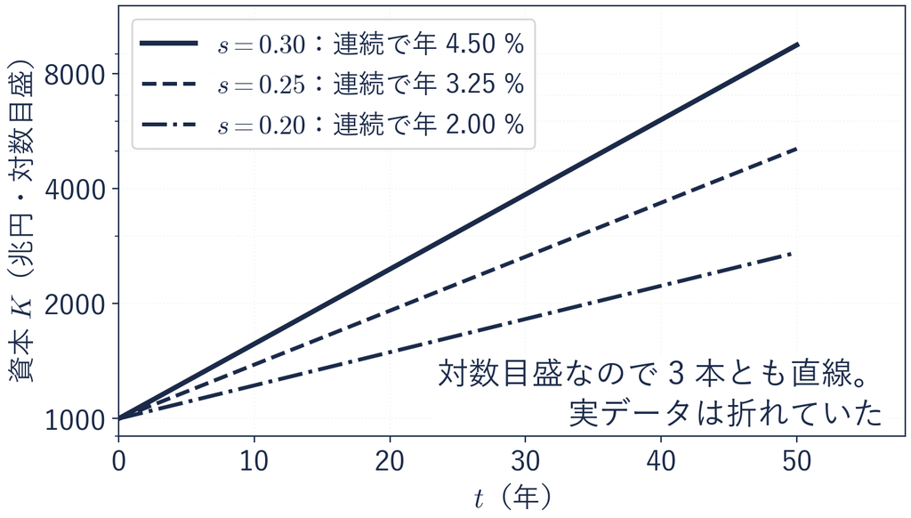

$s$ を $0.2$ から $0.3$ に上げると $r$ は $0.02$ から $0.045$  
ただし、いま使える分は減る

縦は前に出てきた対数目盛なので、$3$ 本とも直線で傾きが $r$

## 例題 5-4 貯蓄率の引き上げ

$A = 0.25$, $\delta = 0.03$ の国。貯蓄率 $s$ を上げると何が起きるか

| 問い | 計算 | 答え |
| --- | --- | --- |
| (1) $s = 0.2$ の連続成長率 | $0.2 \times 0.25 - 0.03$ | $r = 0.02$ |
| (2) $s = 0.28$ の連続成長率 | $0.28 \times 0.25 - 0.03$ | $r = 0.04$ |
| (3) (2) を前年比に直す | $1 + g = e^{0.04} \approx 1.04081$ | $g \approx 0.04081$ |

貯蓄率を上げると、連続で年 $2$ % が年 $4$ % になる

模型が出すのは連続の $r$ ニュースが言うのは前年比の $g$ 見比べる前にそろえる  
前の絵は $s = 0.3$、ここは年 $4$ % ちょうどになる $s = 0.28$ で見る

## ⚠ よくある 3 つの取り違え

✕ こうしがち

$s$ を上げたら  
$K$ の出発点も上がる

$r = sA$ と書いて  
$\delta$ を忘れる

流入を  
$sK$ と書く

○ 正しくは

出発点は $1000$ のまま  
変わるのは傾き

引いて $r = sA - \delta$  
$0.05$ ではなく $0.02$

貯蓄するのは $Y$  
$sY = 50$（$sK$ なら $200$）

$\delta$ が $K$ にかかるので、$s$ も $K$ かと思える。$s$ がかかるのは $Y$ のほう

## 演習 4-1 AK モデルの成長率

演習 4-1

計算ドリル5 のブロック $4$「AK モデル」（全問）。  
動画で答え合わせするのは $3$ と $4$

- **復習 D** $\ln 6 = \ln 2 + \ln 3$ を使って、$\ln 6$ を求める（$\ln 2 \approx 0.69315$, $\ln 3 \approx 1.09861$）
1. $A = 0.3$ で一定の国。資本が $K = 800$ 兆円のとき、産出 $Y$
2. $A = 0.3$ で一定の国。資本が連続で年 $1.5$ % で増えるとき、産出 $Y$ の連続成長率
3. $s = 0.24$, $A = 0.3$, $\delta = 0.04$ の国の連続成長率 $r$
4. $s = 0.15$, $A = 0.2$, $\delta = 0.04$ の国の $r$. 伸びる・横ばい・縮むのどれか

⏸ PAUSE 動画を止めて、ノートに全部解く。$3$ と $4$ が解けたら再生に戻る

## 演習 4-1 の答え 伸びる国

$s = 0.24$, $A = 0.3$, $\delta = 0.04$ の国の連続成長率 $r$

① $sA$ を出す（STEP $1$）

かけてから  
$0.24 \times 0.3 = 0.072$

② $\delta$ を引く（STEP $2$）

$0.072 - 0.04$  
$= 0.032$

③ 符号を見る（STEP $3$）

$0.032$ は正  
だから伸びる

こたえ

$r = 0.032$（連続で年 $3.2$ %・伸びる）

$sA$ を先に出してから $\delta$ を引く。$0.24 \times (0.3 - 0.04)$ ではない

## 演習 4-1 の答え 縮む国

$s = 0.15$, $A = 0.2$, $\delta = 0.04$ の国の $r$ と、伸びる・横ばい・縮む

① $sA$ を出す（STEP $1$）

かけてから  
$0.15 \times 0.2 = 0.03$

② $\delta$ を引く（STEP $2$）

$0.03 - 0.04$  
$= -0.01$

③ 符号を見る（STEP $3$）

$-0.01$ は負  
だから縮む

こたえ

$r = -0.01$（連続で年 $-1$ %・縮む）

$sA = 0.03$ が $\delta = 0.04$ に届かない  
残りの $1$・$2$ と復習 D は、ノートに解き、略解で確かめる

## 演習 4-2 道具の見分け

演習 4-2

計算ドリル5 のブロック $5$「見分けて解く」（全問）。  
どのトピックの道具かを選んでから解く

1. ある国の GDP が $14$ 年で $170$ 兆円から $238$ 兆円になった  
   ならした連続成長率 $r$（$\ln 1.4 \approx 0.33647$・小数第 $4$ 位まで）
2. 売上 ＝ 客数 × 客単価  
   客数が連続で年 $1.8$ %、客単価が連続で年 $-0.3$ % のとき、売上の $r$

目印は見た目 $1$ は額が $2$ つ $2$ は × でつながる式

⏸ PAUSE 動画を止めてノートに解く。答え合わせは略解で

## まとめ

- 刻みを細かくした行き先が「連続で年 $r$」。式は $Y = Y_0e^{rt}$
- 連続成長率は $\ln Y$ のグラフの傾き。一定なら $\ln Y$ は直線
- かけ算でできた量は成長率の足し算、割り算なら引き算
- AK モデル $Y = AK$ の成長率は $r = sA - \delta$
- 貯蓄率 $s$ を上げると、$\ln Y$ の傾きが上がる

**計算ドリル5 のブロック $4$「AK モデル」・$5$「見分けて解く」**の  
残りの問題を解く → 第5回はここまで